# Исключения в Python

**Исключения (exceptions)** - ещё один тип данных в Python. Исключения необходимы для того, чтобы сообщать программисту об ошибках.

Самый простейший пример исключения - деление на ноль:

```python
2 / 0
```

```
---------------------------------------------------------------------------
ZeroDivisionError                         Traceback (most recent call last)
<ipython-input-1-8b4ac6d3a3e1> in <module>
----> 1 2 / 0

ZeroDivisionError: division by zero
```

Разберём это сообщение подробнее:

интерпретатор нам сообщает о том, что он поймал исключение и напечатал информацию **(Traceback (most recent call last))**.

Название исключения (**ZeroDivisionError**) и краткое описание исключения (**division by zero**).

Возможны другие исключения:

```python
'hello' + 2
```

```
---------------------------------------------------------------------------
TypeError                                 Traceback (most recent call last)
<ipython-input-2-a10e3833a80e> in <module>
----> 1 'hello' + 2

TypeError: can only concatenate str (not "int") to str
```

```python
float('hello')
```

```
---------------------------------------------------------------------------
ValueError                                Traceback (most recent call last)
<ipython-input-3-879c4bea9d62> in <module>
----> 1 float('hello')

ValueError: could not convert string to float: 'hello'
```

В этих двух примерах генерируются исключения **TypeError** и **ValueError** соответственно.

### Исключения:

**FloatingPointError** - порождается при неудачном выполнении операции с плавающей запятой. На практике встречается нечасто.

**OverflowError** - возникает, когда результат арифметической операции слишком велик для представления. Не появляется при обычной работе с целыми числами (так как python поддерживает длинные числа), но может возникать в некоторых других случаях.

**ZeroDivisionError** - деление на ноль.

**AttributeError** - объект не имеет данного атрибута (значения или метода).

**EOFError** - функция наткнулась на конец файла и не смогла прочитать то, что хотела.

**ImportError** - не удалось импортирование модуля или его атрибута

**IndexError** - индекс не входит в диапазон элементов.

**KeyError** - несуществующий ключ (в словаре, множестве или другом объекте).

**NameError** - не найдено переменной с таким именем

**FileExistsError** - попытка создания файла или директории, которая уже существует

**FileNotFoundError** - файл или директория не существует

**IndentationError** - неправильные отступы

**TypeError** - операция применена к объекту несоответствующего типа

**ValueError** - функция получает аргумент правильного типа, но некорректного значения

Для обработки исключений используется конструкция try - except.

# Перехват исключений

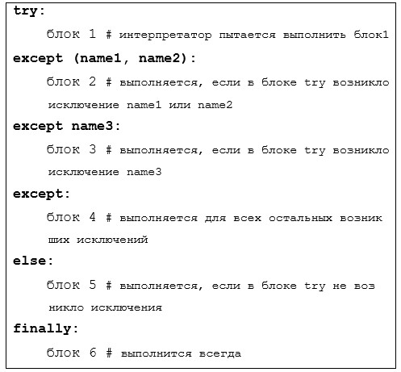

Оператор **try** работает следующим образом:

- в начале исполняется блок **try** (операторы между ключевыми словами try и except);
- если при этом не появляется исключений, **блок except** не выполняется и оператор **try** заканчивает работу;
- если во время выполнения блока **try** было возбуждено какое-либо исключение, оставшаяся часть блока не выполняется. Затем, если тип этого исключения совпадает с исключением, указанным после ключевого слова **except**, выполняется блок except, а по его завершению выполнение продолжается сразу после оператора **try-except**.
- если порождается исключение, не совпадающее по типу с указанным в блоке except — оно передаётся внешним операторам try; если ни одного обработчика не найдено, исключение считается необработанным (unhandled exception), и выполнение полностью останавливается.

Оператор **try** может иметь более одного блока **except** — для описания обработчиков различных исключений. При этом будет выполнен максимум один обработчик. Обработчики ловят только те исключения, которые возникают внутри соответствующего блока try, но не те, которые возникают в других обработчиках этого же самого оператора try-except. Блок except может указывать несколько исключений в виде заключённого в скобки кортежа.

Конструкция else была добавлена к инструкции обработки исключений для того, чтобы мы могли разделить ситуации, не прибегая к использованию флагов, когда выполнение программы продолжилось из-за того, что исключений в блоке try не возникло, или же они были перехвачены и обработаны.

## 1

```python
x = int(input())
```

```
0
```

```python
try:
    y =  1/ x
except ZeroDivisionError:
    y = 0
else:
    print('ok')
print(y)
```

```
0
```

## 2

```python
try:
  print(x)
except NameError:
  print("Переменная x не определена")
except:
  print("Что-то пошло не так")
```

```
0
```

## 3

```python
try:
    x = int(input())
    y = int(input())
    s = 10 + y / x
except ValueError:
  print("Некорректное значение аргумента")
except ZeroDivisionError:
    s = 10
except:
  print("Что-то пошло не так")
print(f's = {s}')
```

```
0
a
Некорректное значение аргумента
```

```
---------------------------------------------------------------------------
NameError                                 Traceback (most recent call last)
<ipython-input-1-80c2ab9ef35f> in <module>
      9 except:
     10   print("Что-то пошло не так")
---> 11 print(f's = {s}')

NameError: name 's' is not defined
```